# Tarefa4 - GeoAnalise e Estatistica Espacial

Gustavo Hotta - A56865193, Rafael Furlan - A56871487, Ricardo Squassina Lee - A56843646

Leio o Shapefile crime_mg:

```r
crime_mg<- readOGR(dsn = "crime_mg", layer = "crime_mg",verbose = TRUE, encoding = "UTF-8",p4s = "+proj=longlat +ellps=WGS84")
names(crime_mg)
```

```
##  [1] "CODMUNI"  "ID"       "MUNIC"    "AREA"     "INDICE94" "INDICE95"
##  [7] "GINI_91"  "POP_94"   "POP_RUR"  "POP_URB"  "POP_FEM"  "POP_MAS"
## [13] "POP_TOT"  "URBLEVEL" "PIB_PC"   "X_COORD"  "Y_COORD"
```

```r
summary(crime_mg)
```

```
## Object of class SpatialPolygonsDataFrame
## Coordinates:
##         min       max
## x -51.06258 -39.85724
## y -22.91696 -14.23725
## Is projected: FALSE
## proj4string : [+proj=longlat +ellps=WGS84]
## Data attributes:
##     CODMUNI           ID                        MUNIC
##  Min.   :  10   Min.   :  0.0   Abadia dos Dourados:  1
##  1st Qu.:1852   1st Qu.:188.2   Abaeté             :  1
##  Median :3645   Median :377.5   Abre-Campo         :  1
##  Mean   :3636   Mean   :377.5   Acaiaca            :  1
##  3rd Qu.:5444   3rd Qu.:566.8   Açucena            :  1
##  Max.   :7220   Max.   :755.0   Água Boa           :  1
##                                 (Other)            :748
##       AREA            INDICE94         INDICE95         GINI_91
##  Min.   :   40.3   Min.   : 0.260   Min.   : 0.420   Min.   :0.0000
##  1st Qu.:  208.9   1st Qu.: 8.143   1st Qu.: 9.643   1st Qu.:0.5129
##  Median :  371.4   Median :12.060   Median :13.975   Median :0.5578
##  Mean   :  779.4   Mean   :13.329   Mean   :15.449   Mean   :0.5330
##  3rd Qu.:  827.5   3rd Qu.:17.203   3rd Qu.:19.820   3rd Qu.:0.5960
##  Max.   :13292.1   Max.   :41.300   Max.   :47.690   Max.   :0.7127
##
##      POP_94           POP_RUR       POP_URB       POP_FEM       POP_MAS
##  Min.   :    820   0      : 33   0      : 33   0      : 33   0      : 33
##  1st Qu.:   4724   1219   :  3   1374   :  3   1042   :  2   1226   :  2
##  Median :   8602   1994   :  3   10429  :  2   1070   :  2   1483   :  2
##  Mean   :  21640   4995   :  3   1120   :  2   1368   :  2   1539   :  2
##  3rd Qu.:  18054   12472  :  2   11996  :  2   1449   :  2   1643   :  2
##  Max.   :2079280   1252   :  2   1257   :  2   1619   :  2   1658   :  2
##                    (Other):708   (Other):710   (Other):711   (Other):711
##     POP_TOT           URBLEVEL          PIB_PC         X_COORD
##  Min.   :      0   Min.   :0.0000   Min.   :    0   Min.   :-50.81
##  1st Qu.:   4295   1st Qu.:0.3743   1st Qu.: 1665   1st Qu.:-45.55
##  Median :   8216   Median :0.5445   Median : 2446   Median :-44.06
##  Mean   :  20865   Mean   :0.5373   Mean   : 3036   Mean   :-44.22
##  3rd Qu.:  17710   3rd Qu.:0.7120   3rd Qu.: 3525   3rd Qu.:-42.76
##  Max.   :2020161   Max.   :0.9970   Max.   :37728   Max.   :-40.03
##
##     Y_COORD
##  Min.   :-22.81
##  1st Qu.:-21.19
##  Median :-20.01
##  Mean   :-19.81
##  3rd Qu.:-18.77
##  Max.   :-14.46
##
```

Mapa de Minas Gerais com os municipios, como no shapefile, sem tema:

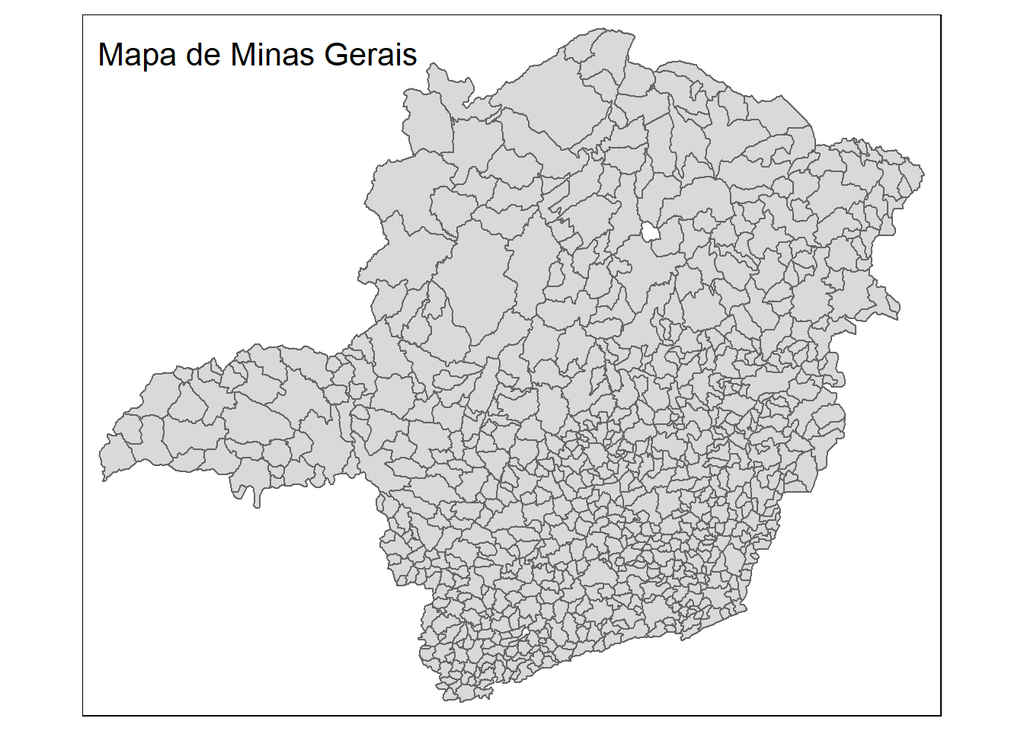

```r
tmap::qtm(crime_mg,title = "Mapa de Minas Gerais")
```

Pergunta 1 Qual das variáveis quantitativas apresentadas no shapefile crime_mg apresenta maior auto-correlação espacial? Descreva como implementou a matriz de vizinhança. Apresente o I de Moran e o mapa de auto-correlação espacial local (LISA map) da variável escolhida e também de pelo menos outras 3 variáveis. Obs: desconsidere as variáveis Codmuni, ID, X_coord e Y_coord nessa análise.

Calculo de Moran’s I para vericação da auto-correlação espacial das variáveis usamos a metodologia Rainha (queen) na matriz de vizinhanca:

```r
#crime_mg_nb <- spdep::(crime_mg, region.id = crime_mg$ID)

crime_mg_nb = poly2nb(crime_mg, queen=TRUE, row.names=crime_mg$X_COORD)
#row.names refers to the unique names of each polygon
crime_mg_nb
```

```
## Neighbour list object:
## Number of regions: 754
## Number of nonzero links: 4302
## Percentage nonzero weights: 0.7567069
## Average number of links: 5.70557
```

```r
crime_mg_w <- nb2listw(crime_mg_nb, style="W")

cmg_munic <- crime_mg$MUNIC
cmg_area <- crime_mg$AREA
cmg_indice94 <- crime_mg$INDICE94
cmg_indice95 <- crime_mg$INDICE95
cmg_gini_91 <- crime_mg$GINI_91
cmg_pop_94 <- crime_mg$POP_94
cmg_pop_rur <- crime_mg$POP_RUR
cmg_pop_urb <- crime_mg$POP_URB
cmg_pop_fem <- crime_mg$POP_FEM
cmg_pop_mas <- crime_mg$POP_MAS
cmg_pop_tot <- crime_mg$POP_TOT
cmg_urblevel <- crime_mg$URBLEVEL
cmg_pib_pc <- crime_mg$PIB_PC

moran_i_munic <- moran(cmg_munic,crime_mg_w, length(crime_mg_nb), Szero(crime_mg_w))
moran_i_area <- moran(cmg_area,crime_mg_w, length(crime_mg_nb), Szero(crime_mg_w))
moran_i_indice94 <- moran(cmg_indice94,crime_mg_w, length(crime_mg_nb), Szero(crime_mg_w))
moran_i_indice95 <- moran(cmg_indice95,crime_mg_w, length(crime_mg_nb), Szero(crime_mg_w))
moran_i_gini_91 <- moran(cmg_gini_91,crime_mg_w, length(crime_mg_nb), Szero(crime_mg_w))
moran_i_pop_94 <- moran(cmg_pop_94,crime_mg_w, length(crime_mg_nb), Szero(crime_mg_w))
moran_i_pop_rur <- moran(cmg_pop_rur,crime_mg_w, length(crime_mg_nb), Szero(crime_mg_w))
moran_i_pop_urb <- moran(cmg_pop_urb,crime_mg_w, length(crime_mg_nb), Szero(crime_mg_w))
moran_i_pop_fem <- moran(cmg_pop_fem,crime_mg_w, length(crime_mg_nb), Szero(crime_mg_w))
moran_i_pop_mas <- moran(cmg_pop_mas,crime_mg_w, length(crime_mg_nb), Szero(crime_mg_w))
moran_i_pop_tot <- moran(cmg_pop_tot,crime_mg_w, length(crime_mg_nb), Szero(crime_mg_w))
moran_i_urblevel <- moran(cmg_urblevel,crime_mg_w, length(crime_mg_nb), Szero(crime_mg_w))
moran_i_pib_pc <- moran(cmg_pib_pc,crime_mg_w, length(crime_mg_nb), Szero(crime_mg_w))
```

Mostrando todas as auto-correlações:

```r
#cat("moran_i_munic", moran_i_munic$I,"\n")
#cat("moran_i_area",moran_i_area$I,"\n")
#cat("moran_i_indice94",moran_i_indice94$I,"\n")
#cat("moran_i_indice95",moran_i_indice95$I,"\n")
#cat("moran_i_gini_91",moran_i_gini_91$I,"\n")
#cat("moran_i_pop_94",moran_i_pop_94$I,"\n")
#cat("moran_i_pop_rur",moran_i_pop_rur$I,"\n")
#cat("moran_i_pop_urb",moran_i_pop_urb$I,"\n")
#cat("moran_i_pop_fem",moran_i_pop_fem$I,"\n")
#cat("moran_i_pop_mas",moran_i_pop_mas$I,"\n")
#cat("moran_i_pop_tot",moran_i_pop_tot$I,"\n")
#cat("moran_i_urblevel",moran_i_urblevel$I,"\n")
#cat("moran_i_pib_pc",moran_i_pib_pc$I,"\n")

#max(c(moran_i_munic$I,moran_i_area$I,moran_i_indice94$I,moran_i_indice95$I,moran_i_gini_91$I,moran_i_pop_94$I,moran_i_pop_rur$I,moran_i_pop_urb$I,moran_i_pop_fem$I,moran_i_pop_mas$I,moran_i_pop_tot$I,moran_i_urblevel$I,moran_i_pib_pc$I))

moran <- c("label","i")
label <- c("moran_i_munic",
  "moran_i_area",
  "moran_i_indice94",
  "moran_i_indice95",
  "moran_i_gini_91",
  "moran_i_pop_94",
  "moran_i_pop_rur",
  "moran_i_pop_urb",
  "moran_i_pop_fem",
  "moran_i_pop_mas",
  "moran_i_pop_tot",
  "moran_i_urblevel",
  "moran_i_pib_pc"
)

moran_i <- c(moran_i_munic$I
  ,moran_i_area$I
  ,moran_i_indice94$I
  ,moran_i_indice95$I
  ,moran_i_gini_91$I
  ,moran_i_pop_94$I
  ,moran_i_pop_rur$I
  ,moran_i_pop_urb$I
  ,moran_i_pop_fem$I
  ,moran_i_pop_mas$I
  ,moran_i_pop_tot$I
  ,moran_i_urblevel$I
  ,moran_i_pib_pc$I
)

moran <- data.frame(label = label, moran_i = moran_i)

moran[order(moran$moran_i,decreasing = TRUE),]
```

|  | label | moran_i |
| --- | --- | --- |
| 2 | moran_i_area | 0.551407744 |
| 3 | moran_i_indice94 | 0.315766199 |
| 4 | moran_i_indice95 | 0.302517958 |
| 12 | moran_i_urblevel | 0.291334697 |
| 5 | moran_i_gini_91 | 0.130387445 |
| 6 | moran_i_pop_94 | 0.130170365 |
| 13 | moran_i_pib_pc | 0.122220734 |
| 11 | moran_i_pop_tot | 0.121612301 |
| 1 | moran_i_munic | 0.017806482 |
| 9 | moran_i_pop_fem | 0.011313607 |

[output cut: 3 more lines]

Mostrando Moran’s I das variáveis AREA, INDICE94 e INDICE95, que possuem os maiores I:

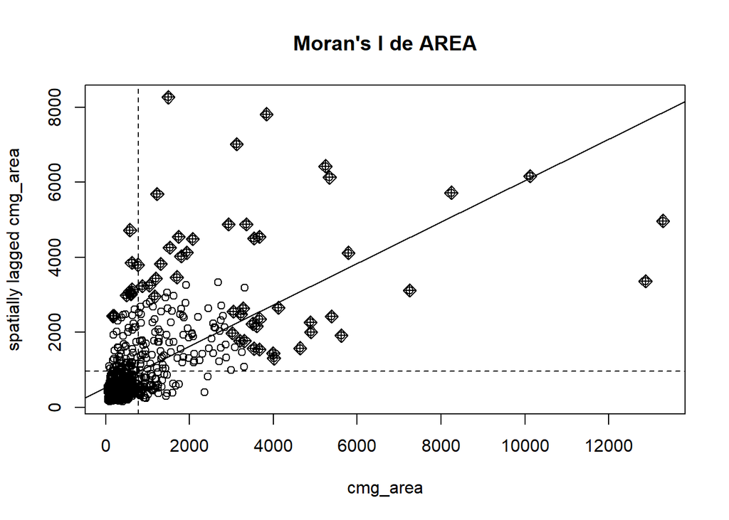

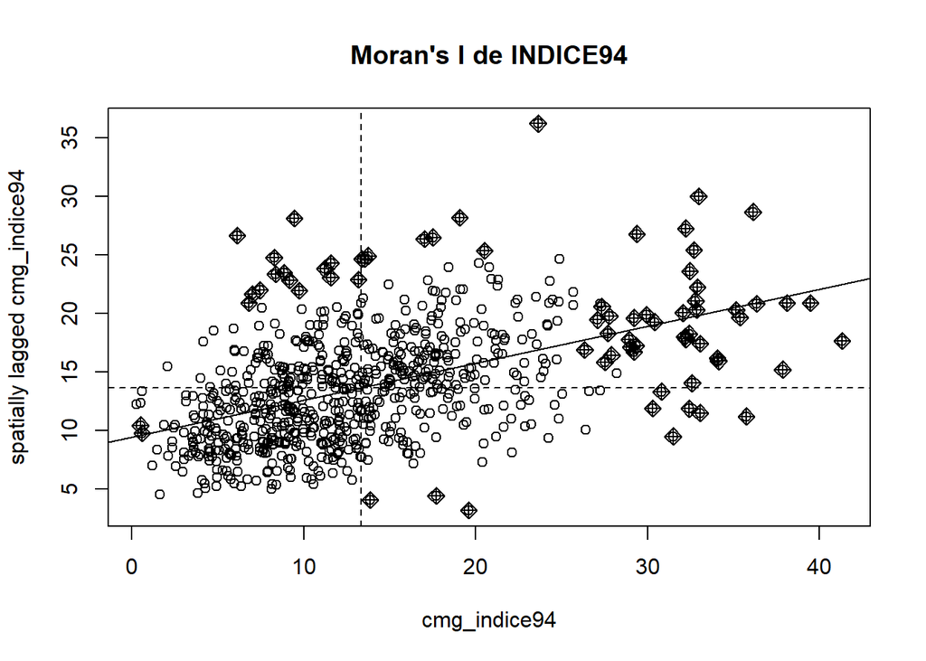

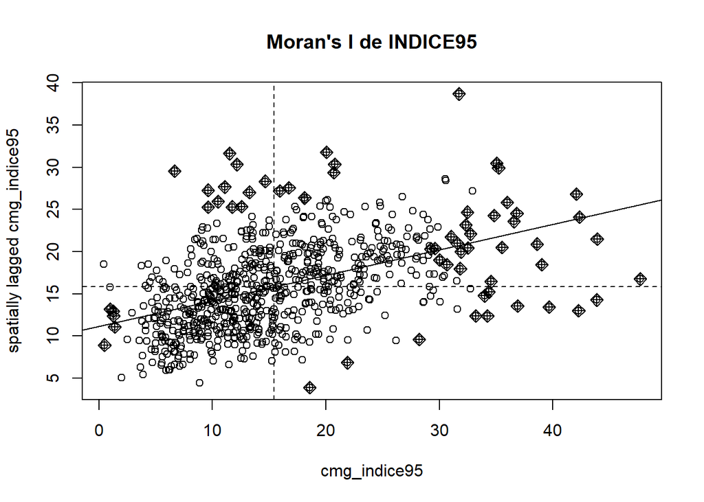

```r
{
  moran.plot(x = cmg_area,listw = crime_mg_w,labels = FALSE)
  title("Moran's I de AREA")
  moran.plot(x = cmg_indice94,listw = crime_mg_w,labels = FALSE)
  title("Moran's I de INDICE94")
  moran.plot(x = cmg_indice95,listw = crime_mg_w,labels = FALSE)
  title("Moran's I de INDICE95")
}
```

Calculando LISA

Verificando a média de links entre vizinhos:

```r
crime_mg_nb
```

```
## Neighbour list object:
## Number of regions: 754
## Number of nonzero links: 4302
## Percentage nonzero weights: 0.7567069
## Average number of links: 5.70557
```

```r
LISA_AREA <- lisa(x = crime_mg$X_COORD, y = crime_mg$Y_COORD, z = crime_mg$AREA, neigh = 5.7)
LISA_INDICE94 <- lisa(x = crime_mg$X_COORD, y = crime_mg$Y_COORD, z = crime_mg$INDICE94, neigh = 5.7)
LISA_INDICE95 <- lisa(x = crime_mg$X_COORD, y = crime_mg$Y_COORD, z = crime_mg$INDICE95, neigh = 5.7)
```

Plot dos mapas LISA:

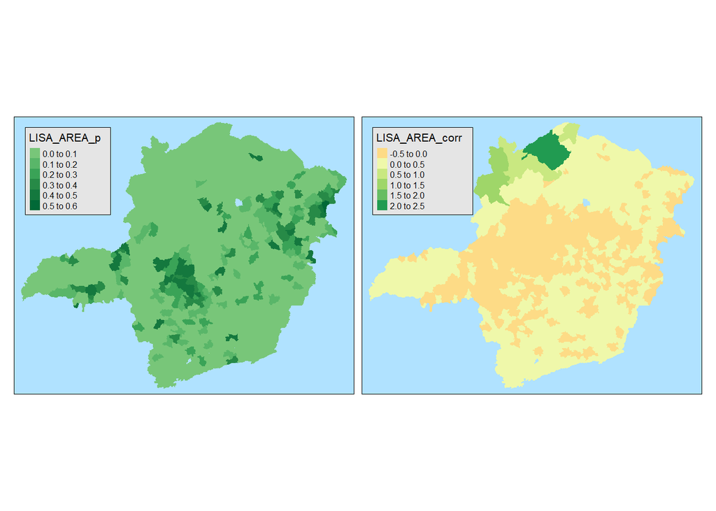

```r
crime_mg$LISA_AREA_p <- LISA_AREA$p
crime_mg$LISA_INDICE94_p <- LISA_INDICE94$p
crime_mg$LISA_INDICE95_p <- LISA_INDICE95$p

#tmap::qtm(crime_mg, fill = "LISA_AREA_p", style = "natural")
#tmap::qtm(crime_mg, fill = "LISA_INDICE94_p", style = "natural")
#tmap::qtm(crime_mg, fill = "LISA_INDICE95_p", style = "natural")

crime_mg$LISA_AREA_dmean <- LISA_AREA$dmean
crime_mg$LISA_INDICE94_dmean <- LISA_INDICE94$dmean
crime_mg$LISA_INDICE95_dmean <- LISA_INDICE95$dmean

#tmap::qtm(crime_mg, fill = "LISA_AREA_dmean", style = "natural")
#tmap::qtm(crime_mg, fill = "LISA_INDICE94_dmean", style = "natural")
#tmap::qtm(crime_mg, fill = "LISA_INDICE95_dmean", style = "natural")

crime_mg$LISA_AREA_corr <- LISA_AREA$correlation
crime_mg$LISA_INDICE94_corr <- LISA_INDICE94$correlation
crime_mg$LISA_INDICE95_corr <- LISA_INDICE95$correlation

#tmap::qtm(crime_mg, fill = "LISA_AREA_corr", style = "natural")
#tmap::qtm(crime_mg, fill = "LISA_INDICE94_corr", style = "natural")
#tmap::qtm(crime_mg, fill = "LISA_INDICE95_corr", style = "natural")


tmap::tm_shape(crime_mg) +
#  tmap::tm_fill(c("LISA_AREA_p","LISA_AREA_dmean","LISA_AREA_corr"), midpoint = 0) +
  tmap::tm_fill(c("LISA_AREA_p","LISA_AREA_corr"), midpoint = 0) +
  tmap::tm_style("natural")
```

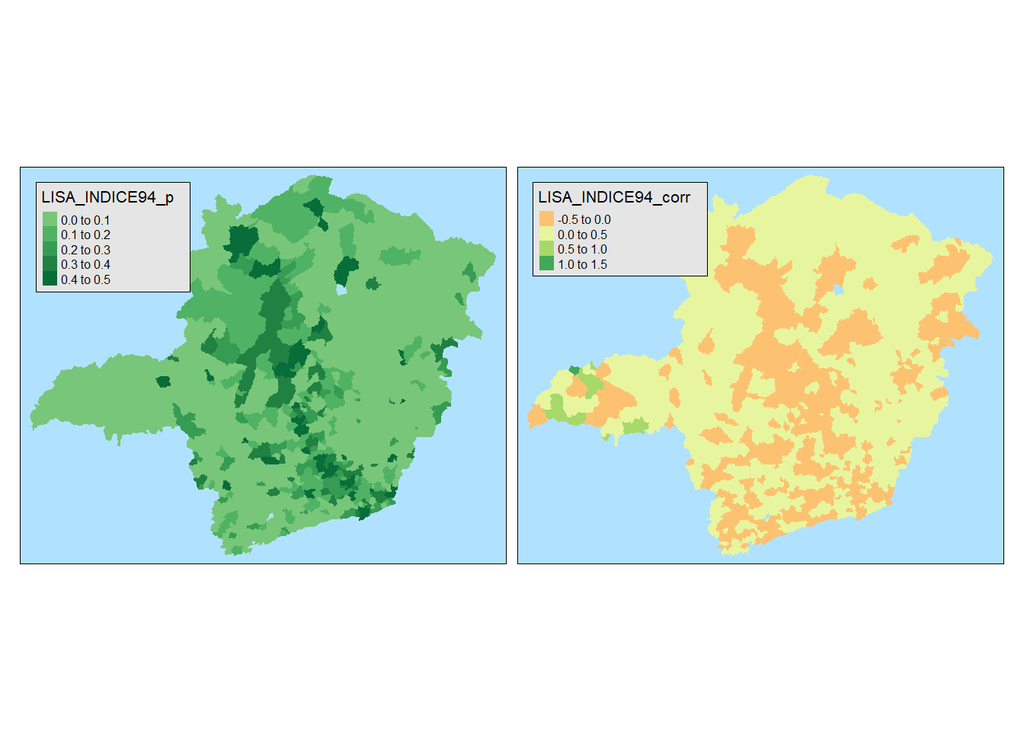

```r
tmap::tm_shape(crime_mg) +
#  tmap::tm_fill(c("LISA_INDICE94_p","LISA_INDICE94_dmean","LISA_INDICE94_corr"), midpoint = 0) +
  tmap::tm_fill(c("LISA_INDICE94_p","LISA_INDICE94_corr"), midpoint = 0) +
  tmap::tm_style("natural")
```

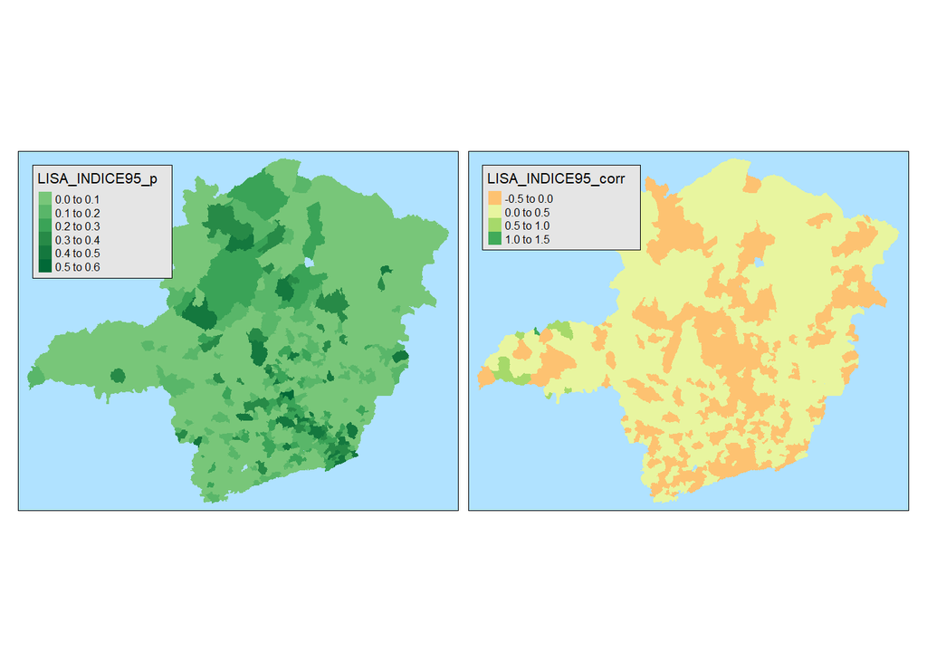

```r
tmap::tm_shape(crime_mg) +
#  tmap::tm_fill(c("LISA_INDICE95_p","LISA_INDICE95_dmean","LISA_INDICE95_corr"), midpoint = 0) +
  tmap::tm_fill(c("LISA_INDICE95_p","LISA_INDICE95_corr"), midpoint = 0) +
  tmap::tm_style("natural")
```

(Fizemos também a implementação dos mapas LISA no GeoDa, e estes foram diferentes do apresentado aqui)

Pergunta 2 Implemente o modelo espacial auto-regressivo (SAR) da variável Indice95 (índice de criminalidade em 1995 de Minas Gerais) a partir de apenas uma variável independente (não pode ser Indice94, Codmuni, ID, X_coord nem Y_coord). Apresente o resultado da regressão linear simples e da regressão linear espacial. Apresente as equações e interprete seus coeficientes.

Regrssão linear simples

```r
ap <- as.data.frame(cbind(crime_mg$MUNIC, crime_mg$AREA, crime_mg$INDICE94,
                          crime_mg$INDICE95, crime_mg$GINI_91, crime_mg$POP_94,
                          crime_mg$POP_RUR, crime_mg$POP_URB, crime_mg$POP_FEM,
                          crime_mg$POP_MAS, crime_mg$POP_TOT, crime_mg$URBLEVEL,
                          crime_mg$PIB_PC))
colnames(ap) <- c("ID",names(crime_mg@data[4:15]))

head(ap)
```

|  | ID | AREA | INDICE94 | INDICE95 | GINI_91 | POP_94 | POP_RUR | POP_URB | POP_FEM | POP_MAS | POP_TOT | URBLEVEL | PIB_PC |
| --- | --- | --- | --- | --- | --- | --- | --- | --- | --- | --- | --- | --- | --- |
| 1 | 1 | 897.4 | 11.22 | 17.28 | 0.5372 | 6291 | 306 | 396 | 362 | 377 | 6492 | 0.541 | 3649 |
| 2 | 2 | 1822.4 | 32.88 | 36.57 | 0.6034 | 21257 | 467 | 159 | 14 | 9 | 20689 | 0.771 | 4124 |
| 3 | 3 | 636.4 | 4.47 | 7.46 | 0.5643 | 19106 | 67 | 543 | 681 | 690 | 18961 | 0.304 | 2147 |
| 4 | 4 | 101.2 | 9.20 | 10.15 | 0.5069 | 3679 | 136 | 203 | 167 | 164 | 3589 | 0.532 | 1720 |
| 5 | 5 | 1172.2 | 8.90 | 10.41 | 0.5163 | 24318 | 21 | 121 | 65 | 53 | 24849 | 0.566 | 1569 |
| 6 | 6 | 1321.9 | 7.60 | 11.89 | 0.5796 | 15340 | 59 | 326 | 619 | 624 | 15769 | 0.178 | 1662 |

```r
lm.ap <- step(lm(crime_mg$INDICE95 ~ ., data=ap))
```

```
## Start:  AIC=2234.09
## crime_mg$INDICE95 ~ ID + AREA + INDICE94 + GINI_91 + POP_94 +
##     POP_RUR + POP_URB + POP_FEM + POP_MAS + POP_TOT + URBLEVEL +
##     PIB_PC
##
##            Df Sum of Sq   RSS    AIC
## - AREA      1       3.8 14103 2232.3
## - ID        1       6.2 14106 2232.4
## - POP_MAS   1      10.7 14110 2232.7
## - POP_FEM   1      14.5 14114 2232.9
## - POP_RUR   1      15.7 14115 2232.9
## - POP_URB   1      18.3 14118 2233.1
## - POP_TOT   1      18.3 14118 2233.1
## - POP_94    1      18.6 14118 2233.1
## <none>                  14100 2234.1
## - PIB_PC    1      41.8 14141 2234.3
## - GINI_91   1     232.1 14332 2244.4
## - URBLEVEL  1     480.7 14580 2257.4
## - INDICE94  1   18251.9 32351 2858.3
##
## Step:  AIC=2232.29
## crime_mg$INDICE95 ~ ID + INDICE94 + GINI_91 + POP_94 + POP_RUR +
##     POP_URB + POP_FEM + POP_MAS + POP_TOT + URBLEVEL + PIB_PC
##
##            Df Sum of Sq   RSS    AIC
## - ID        1       6.4 14110 2230.6
## - POP_MAS   1      11.7 14115 2230.9
## - POP_FEM   1      15.3 14119 2231.1
## - POP_RUR   1      16.6 14120 2231.2
## - POP_URB   1      18.5 14122 2231.3
## - POP_TOT   1      20.5 14124 2231.4
## - POP_94    1      20.7 14124 2231.4
## <none>                  14103 2232.3
## - PIB_PC    1      41.4 14145 2232.5
## - GINI_91   1     231.5 14335 2242.6
## - URBLEVEL  1     477.9 14581 2255.4
## - INDICE94  1   18434.4 32538 2860.6
##
## Step:  AIC=2230.64
## crime_mg$INDICE95 ~ INDICE94 + GINI_91 + POP_94 + POP_RUR + POP_URB +
```

[output cut: 88 more lines]

```
##            Df Sum of Sq   RSS    AIC
## - PIB_PC    1      36.5 14220 2222.5
## <none>                  14183 2222.6
## - GINI_91   1     234.5 14418 2232.9
## - URBLEVEL  1     454.0 14637 2244.3
## - INDICE94  1   19027.5 33211 2862.1
##
## Step:  AIC=2222.5
## crime_mg$INDICE95 ~ INDICE94 + GINI_91 + URBLEVEL
##
##            Df Sum of Sq   RSS    AIC
## <none>                  14220 2222.5
## - GINI_91   1     252.2 14472 2233.8
## - URBLEVEL  1     550.7 14771 2249.2
## - INDICE94  1   19206.1 33426 2864.9
```

```r
lm.ap
```

```
##
## Call:
## lm(formula = crime_mg$INDICE95 ~ INDICE94 + GINI_91 + URBLEVEL,
##     data = ap)
##
## Coefficients:
## (Intercept)     INDICE94      GINI_91     URBLEVEL
##      4.6200       0.8295      -5.8052       5.3346
```

```r
summary(lm.ap)
```

```
##
## Call:
## lm(formula = crime_mg$INDICE95 ~ INDICE94 + GINI_91 + URBLEVEL,
##     data = ap)
##
## Residuals:
##      Min       1Q   Median       3Q      Max
## -16.6372  -2.4362  -0.2178   2.3819  29.1584
##
## Coefficients:
##             Estimate Std. Error t value Pr(>|t|)
## (Intercept)  4.62004    0.72718   6.353 3.65e-10 ***
## INDICE94     0.82950    0.02606  31.827  < 2e-16 ***
## GINI_91     -5.80519    1.59168  -3.647 0.000283 ***
## URBLEVEL     5.33462    0.98980   5.390 9.47e-08 ***
## ---
## Signif. codes:  0 '***' 0.001 '**' 0.01 '*' 0.05 '.' 0.1 ' ' 1
##
## Residual standard error: 4.354 on 750 degrees of freedom
## Multiple R-squared:  0.6982, Adjusted R-squared:  0.697
## F-statistic: 578.3 on 3 and 750 DF,  p-value: < 2.2e-16
```

```r
lmK <- lm(formula = crime_mg$INDICE95 ~ INDICE94 + GINI_91 + URBLEVEL,
    data = ap)

summary(lmK)
```

```
##
## Call:
## lm(formula = crime_mg$INDICE95 ~ INDICE94 + GINI_91 + URBLEVEL,
##     data = ap)
##
## Residuals:
##      Min       1Q   Median       3Q      Max
## -16.6372  -2.4362  -0.2178   2.3819  29.1584
##
## Coefficients:
##             Estimate Std. Error t value Pr(>|t|)
## (Intercept)  4.62004    0.72718   6.353 3.65e-10 ***
## INDICE94     0.82950    0.02606  31.827  < 2e-16 ***
## GINI_91     -5.80519    1.59168  -3.647 0.000283 ***
## URBLEVEL     5.33462    0.98980   5.390 9.47e-08 ***
## ---
## Signif. codes:  0 '***' 0.001 '**' 0.01 '*' 0.05 '.' 0.1 ' ' 1
##
## Residual standard error: 4.354 on 750 degrees of freedom
## Multiple R-squared:  0.6982, Adjusted R-squared:  0.697
## F-statistic: 578.3 on 3 and 750 DF,  p-value: < 2.2e-16
```

Regressão linear espacial - SAR

```r
ap <- as.data.frame(cbind(crime_mg$MUNIC, crime_mg$AREA, crime_mg$INDICE94,
                          crime_mg$INDICE95, crime_mg$GINI_91, crime_mg$POP_94,
                          crime_mg$POP_RUR, crime_mg$POP_URB, crime_mg$POP_FEM,
                          crime_mg$POP_MAS, crime_mg$POP_TOT, crime_mg$URBLEVEL,
                          crime_mg$PIB_PC))
colnames(ap) <- c("ID",names(crime_mg@data[4:15]))

#crime_mg_nb <- spdep::(crime_mg, region.id = crime_mg$ID)

crime_mg_nb = poly2nb(crime_mg, queen=TRUE, row.names=crime_mg$X_COORD)
#row.names refers to the unique names of each polygon
crime_mg_nb
```

```
## Neighbour list object:
## Number of regions: 754
## Number of nonzero links: 4302
## Percentage nonzero weights: 0.7567069
## Average number of links: 5.70557
```

```r
crime_mg_w <- nb2listw(crime_mg_nb, style="W")


############################################################################
# SAR - Spatial Autoregressive lag model ###################################
# (k nearest neighbours [k from AIC Gaussian minimisation]) ################
############################################################################

#sarGauss <- spdep::sacsarlm(crime_mg$INDICE95 ~ INDICE94 + GINI_91 + URBLEVEL,data=ap, #crime_mg_w,type = "sac")

#summary(sarGauss)

#ksarGauss <- round(sarGauss$rho.se * length(ap[,1]))

# create spatial weights using k nearest neighbours (knearneigh command)
# and convert to a W matrix style (knn2nb and nb2listw commands)
#myknn <- knearneigh(coords,k=ksarGauss,longlat=FALSE,RANN=FALSE)
#mynb <- knn2nb(myknn,sym=TRUE)
#mylistw <- nb2listw(mynb,style="W")

# "lagsarlm" is the function that implements SAR Lag model in R
sar.ap <- lagsarlm(crime_mg$INDICE95~ INDICE94 + GINI_91 +
                     URBLEVEL,data=ap,crime_mg_w,method="Matrix")

# store RSS and R2 of the SAR lag model
SARk_SSE <- sar.ap$SSE

SST <- sum((ap$INDICE95 - mean(ap$INDICE95))^2)

r2_SARk <- 1 - (SARk_SSE/SST)
r2_SARk
```

```
## [1] 0.7029335
```

```r
summary(sar.ap)
```

```
##
## Call:
## lagsarlm(formula = crime_mg$INDICE95 ~ INDICE94 + GINI_91 + URBLEVEL,
##     data = ap, listw = crime_mg_w, method = "Matrix")
##
## Residuals:
##       Min        1Q    Median        3Q       Max
## -16.43661  -2.38664  -0.19365   2.28926  28.43605
##
## Type: lag
## Coefficients: (asymptotic standard errors)
##             Estimate Std. Error z value  Pr(>|z|)
## (Intercept)  3.36490    0.82039  4.1016 4.103e-05
## INDICE94     0.80411    0.02706 29.7163 < 2.2e-16
## GINI_91     -5.30895    1.58190 -3.3561 0.0007906
## URBLEVEL     4.67296    0.99603  4.6916 2.711e-06
##
## Rho: 0.10647, LR test value: 10.464, p-value: 0.0012169
## Asymptotic standard error: 0.033258
##     z-value: 3.2013, p-value: 0.0013679
## Wald statistic: 10.249, p-value: 0.0013679
##
## Log likelihood: -2171.899 for lag model
## ML residual variance (sigma squared): 18.562, (sigma: 4.3083)
## Number of observations: 754
## Number of parameters estimated: 6
## AIC: 4355.8, (AIC for lm: 4364.3)
## LM test for residual autocorrelation
## test value: 0.10235, p-value: 0.74902
```

Pergunta 3 Para essa variável que você escolheu, o modelo espacial SAR apresentou ganhos significantes com relação ao modelo linear simples? Justifique sua resposta. Obs: Sugere-se fazer essa atividade no GeoDA ou no R.

```r
cat("Rˆ2 SAR: ",r2_SARk, "\n")
```

```
## Rˆ2 SAR:  0.7029335
```

```r
cat("Rˆ2 LM:",summary(lmK)$adj.r.squared,"\n")
```

```
## Rˆ2 LM: 0.6969645
```

O modelo espacial SAR apresentou ganho de 1% versus o modelo linear simples.

Pergunta 4 Implemente a regressão espacial GWR da variável Indice95 (índice de criminalidade em 1995 de Minas Gerais) a partir de apenas uma variável independente (não pode ser Indice94, Codmuni, ID, X_coord nem Y_coord). Apresente o resultado da regressão linear simples e da regressão linear espacial por GWR. Apresente medidas da distribuição dos coeficientes (min, Q1, Q2, Q3, máx), e da distribuição do R2 (min, Q1, Q2, Q3, máx) e apresente os resultados globais da regressão (R2 global, basicamente). Obs: Sugere-se fazer essa atividade no ArcGIS ou no R.

```r
coords <- cbind(crime_mg$X_COORD,crime_mg$Y_COORD)
colnames(coords) <- c("X","Y")

ap <- as.data.frame(cbind(crime_mg$MUNIC, crime_mg$AREA, crime_mg$INDICE94,
                          crime_mg$INDICE95, crime_mg$GINI_91, crime_mg$POP_94,
                          crime_mg$POP_RUR, crime_mg$POP_URB, crime_mg$POP_FEM,
                          crime_mg$POP_MAS, crime_mg$POP_TOT, crime_mg$URBLEVEL,
                          crime_mg$PIB_PC))
colnames(ap) <- c("ID",names(crime_mg@data[4:15]))

bwGauss <- gwr.sel(crime_mg$INDICE95 ~ INDICE94 + GINI_91 + URBLEVEL,data=ap,coords=coords,adapt=TRUE,method="aic",
                   gweight=gwr.Gauss,verbose=FALSE)

gwr.ap <- gwr(crime_mg$INDICE95 ~ INDICE94 + GINI_91 +
                 URBLEVEL, data=ap,coords=coords,bandwidth=bwGauss,
               gweight=gwr.Gauss,adapt=bwGauss,hatmatrix=TRUE)
gwr.ap
```

```
## Call:
## gwr(formula = crime_mg$INDICE95 ~ INDICE94 + GINI_91 + URBLEVEL,
##     data = ap, coords = coords, bandwidth = bwGauss, gweight = gwr.Gauss,
##     adapt = bwGauss, hatmatrix = TRUE)
## Kernel function: gwr.Gauss
## Adaptive quantile: 0.0411007 (about 30 of 754 data points)
## Summary of GWR coefficient estimates at data points:
##                   Min.   1st Qu.    Median   3rd Qu.      Max.  Global
## X.Intercept.  -2.68291   2.58872   3.82700   8.52713  20.59749  4.6200
## INDICE94       0.62641   0.75768   0.80116   0.83534   1.02374  0.8295
## GINI_91      -27.22302 -11.11227  -5.72057  -0.53447  13.64553 -5.8052
## URBLEVEL      -2.24401   2.25196   5.03699   8.09010  12.19130  5.3346
## Number of data points: 754
## Effective number of parameters (residual: 2traceS - traceS'S): 66.21814
## Effective degrees of freedom (residual: 2traceS - traceS'S): 687.7819
## Sigma (residual: 2traceS - traceS'S): 4.135734
## Effective number of parameters (model: traceS): 46.62188
## Effective degrees of freedom (model: traceS): 707.3781
## Sigma (model: traceS): 4.078046
## Sigma (ML): 3.949956
## AICc (GWR p. 61, eq 2.33; p. 96, eq. 4.21): 4313.115
## AIC (GWR p. 96, eq. 4.22): 4257.927
## Residual sum of squares: 11764.02
## Quasi-global R2: 0.7503001
```

```r
GWR_SSE <- gwr.ap$results$rss
r2_GWR <- 1 - (GWR_SSE/SST)
r2_GWR
```

```
## [1] 0.7503001
```

Pergunta 5 Para essa variável que você escolheu, o modelo espacial GWR apresentou ganhos significantes com relação ao modelo linear simples? Justifique sua resposta.

```r
cat("Rˆ2 SAR: ",r2_SARk, "\n")
```

```
## Rˆ2 SAR:  0.7029335
```

```r
cat("Rˆ2 GWR: ",r2_GWR, "\n")
```

```
## Rˆ2 GWR:  0.7503001
```

GWR Aumenta 5% o ganho em relação ao SAR.

Pergunta 6 Implemente um modelo de regressão linear multivariado stepwise da variável Indice95 (significante a 5% ou 10%, utilize o que achar melhor). Depois, “promova-o” a um modelo SAR. Apresente os resultados comparados (equação, R2). Qual modelo você escolheria como final? Se desejar, apresente mapas que sustente sua justificativa.

```r
ap <- as.data.frame(cbind(crime_mg$MUNIC, crime_mg$AREA, crime_mg$INDICE94,
                          crime_mg$INDICE95, crime_mg$GINI_91, crime_mg$POP_94,
                          crime_mg$POP_RUR, crime_mg$POP_URB, crime_mg$POP_FEM,
                          crime_mg$POP_MAS, crime_mg$POP_TOT, crime_mg$URBLEVEL,
                          crime_mg$PIB_PC))
colnames(ap) <- c("ID",names(crime_mg@data[4:15]))

head(ap)
```

|  | ID | AREA | INDICE94 | INDICE95 | GINI_91 | POP_94 | POP_RUR | POP_URB | POP_FEM | POP_MAS | POP_TOT | URBLEVEL | PIB_PC |
| --- | --- | --- | --- | --- | --- | --- | --- | --- | --- | --- | --- | --- | --- |
| 1 | 1 | 897.4 | 11.22 | 17.28 | 0.5372 | 6291 | 306 | 396 | 362 | 377 | 6492 | 0.541 | 3649 |
| 2 | 2 | 1822.4 | 32.88 | 36.57 | 0.6034 | 21257 | 467 | 159 | 14 | 9 | 20689 | 0.771 | 4124 |
| 3 | 3 | 636.4 | 4.47 | 7.46 | 0.5643 | 19106 | 67 | 543 | 681 | 690 | 18961 | 0.304 | 2147 |
| 4 | 4 | 101.2 | 9.20 | 10.15 | 0.5069 | 3679 | 136 | 203 | 167 | 164 | 3589 | 0.532 | 1720 |
| 5 | 5 | 1172.2 | 8.90 | 10.41 | 0.5163 | 24318 | 21 | 121 | 65 | 53 | 24849 | 0.566 | 1569 |
| 6 | 6 | 1321.9 | 7.60 | 11.89 | 0.5796 | 15340 | 59 | 326 | 619 | 624 | 15769 | 0.178 | 1662 |

```r
lm.ap <- step(lm(crime_mg$INDICE95 ~ ., data=ap))
```

```
## Start:  AIC=2234.09
## crime_mg$INDICE95 ~ ID + AREA + INDICE94 + GINI_91 + POP_94 +
##     POP_RUR + POP_URB + POP_FEM + POP_MAS + POP_TOT + URBLEVEL +
##     PIB_PC
##
##            Df Sum of Sq   RSS    AIC
## - AREA      1       3.8 14103 2232.3
## - ID        1       6.2 14106 2232.4
## - POP_MAS   1      10.7 14110 2232.7
## - POP_FEM   1      14.5 14114 2232.9
## - POP_RUR   1      15.7 14115 2232.9
## - POP_URB   1      18.3 14118 2233.1
## - POP_TOT   1      18.3 14118 2233.1
## - POP_94    1      18.6 14118 2233.1
## <none>                  14100 2234.1
## - PIB_PC    1      41.8 14141 2234.3
## - GINI_91   1     232.1 14332 2244.4
## - URBLEVEL  1     480.7 14580 2257.4
## - INDICE94  1   18251.9 32351 2858.3
##
## Step:  AIC=2232.29
## crime_mg$INDICE95 ~ ID + INDICE94 + GINI_91 + POP_94 + POP_RUR +
##     POP_URB + POP_FEM + POP_MAS + POP_TOT + URBLEVEL + PIB_PC
##
##            Df Sum of Sq   RSS    AIC
## - ID        1       6.4 14110 2230.6
## - POP_MAS   1      11.7 14115 2230.9
## - POP_FEM   1      15.3 14119 2231.1
## - POP_RUR   1      16.6 14120 2231.2
## - POP_URB   1      18.5 14122 2231.3
## - POP_TOT   1      20.5 14124 2231.4
## - POP_94    1      20.7 14124 2231.4
## <none>                  14103 2232.3
## - PIB_PC    1      41.4 14145 2232.5
## - GINI_91   1     231.5 14335 2242.6
## - URBLEVEL  1     477.9 14581 2255.4
## - INDICE94  1   18434.4 32538 2860.6
##
## Step:  AIC=2230.64
## crime_mg$INDICE95 ~ INDICE94 + GINI_91 + POP_94 + POP_RUR + POP_URB +
```

[output cut: 88 more lines]

```
##            Df Sum of Sq   RSS    AIC
## - PIB_PC    1      36.5 14220 2222.5
## <none>                  14183 2222.6
## - GINI_91   1     234.5 14418 2232.9
## - URBLEVEL  1     454.0 14637 2244.3
## - INDICE94  1   19027.5 33211 2862.1
##
## Step:  AIC=2222.5
## crime_mg$INDICE95 ~ INDICE94 + GINI_91 + URBLEVEL
##
##            Df Sum of Sq   RSS    AIC
## <none>                  14220 2222.5
## - GINI_91   1     252.2 14472 2233.8
## - URBLEVEL  1     550.7 14771 2249.2
## - INDICE94  1   19206.1 33426 2864.9
```

```r
lm.ap
```

```
##
## Call:
## lm(formula = crime_mg$INDICE95 ~ INDICE94 + GINI_91 + URBLEVEL,
##     data = ap)
##
## Coefficients:
## (Intercept)     INDICE94      GINI_91     URBLEVEL
##      4.6200       0.8295      -5.8052       5.3346
```

```r
summary(lm.ap)
```

```
##
## Call:
## lm(formula = crime_mg$INDICE95 ~ INDICE94 + GINI_91 + URBLEVEL,
##     data = ap)
##
## Residuals:
##      Min       1Q   Median       3Q      Max
## -16.6372  -2.4362  -0.2178   2.3819  29.1584
##
## Coefficients:
##             Estimate Std. Error t value Pr(>|t|)
## (Intercept)  4.62004    0.72718   6.353 3.65e-10 ***
## INDICE94     0.82950    0.02606  31.827  < 2e-16 ***
## GINI_91     -5.80519    1.59168  -3.647 0.000283 ***
## URBLEVEL     5.33462    0.98980   5.390 9.47e-08 ***
## ---
## Signif. codes:  0 '***' 0.001 '**' 0.01 '*' 0.05 '.' 0.1 ' ' 1
##
## Residual standard error: 4.354 on 750 degrees of freedom
## Multiple R-squared:  0.6982, Adjusted R-squared:  0.697
## F-statistic: 578.3 on 3 and 750 DF,  p-value: < 2.2e-16
```

```r
lm(formula = crime_mg$INDICE95 ~ INDICE94 + GINI_91 + URBLEVEL,
    data = ap)
```

```
##
## Call:
## lm(formula = crime_mg$INDICE95 ~ INDICE94 + GINI_91 + URBLEVEL,
##     data = ap)
##
## Coefficients:
## (Intercept)     INDICE94      GINI_91     URBLEVEL
##      4.6200       0.8295      -5.8052       5.3346
```

```r
sar.ap <- lagsarlm(crime_mg$INDICE95 ~ INDICE94 + GINI_91 +
                     URBLEVEL,data=ap,crime_mg_w,method="Matrix")

# store RSS and R2 of the SAR lag model
SARk_SSE <- sar.ap$SSE

SST <- sum((ap$INDICE95 - mean(ap$INDICE95))^2)

r2_SARk <- 1 - (SARk_SSE/SST)
r2_SARk
```

```
## [1] 0.7029335
```

```r
summary(sar.ap)
```

```
##
## Call:
## lagsarlm(formula = crime_mg$INDICE95 ~ INDICE94 + GINI_91 + URBLEVEL,
##     data = ap, listw = crime_mg_w, method = "Matrix")
##
## Residuals:
##       Min        1Q    Median        3Q       Max
## -16.43661  -2.38664  -0.19365   2.28926  28.43605
##
## Type: lag
## Coefficients: (asymptotic standard errors)
##             Estimate Std. Error z value  Pr(>|z|)
## (Intercept)  3.36490    0.82039  4.1016 4.103e-05
## INDICE94     0.80411    0.02706 29.7163 < 2.2e-16
## GINI_91     -5.30895    1.58190 -3.3561 0.0007906
## URBLEVEL     4.67296    0.99603  4.6916 2.711e-06
##
## Rho: 0.10647, LR test value: 10.464, p-value: 0.0012169
## Asymptotic standard error: 0.033258
##     z-value: 3.2013, p-value: 0.0013679
## Wald statistic: 10.249, p-value: 0.0013679
##
## Log likelihood: -2171.899 for lag model
## ML residual variance (sigma squared): 18.562, (sigma: 4.3083)
## Number of observations: 754
## Number of parameters estimated: 6
## AIC: 4355.8, (AIC for lm: 4364.3)
## LM test for residual autocorrelation
## test value: 0.10235, p-value: 0.74902
```

Pergunta 7 (bônus) Promova o modelo final linear da Pergunta 6 a um modelo GWR. Apresente os resultados comparados (equação, R2). Qual modelo você escolheria como final? Se desejar, apresente mapas que sustente sua justificativa.

```r
bwGauss <- gwr.sel(crime_mg$INDICE95 ~ INDICE94 + GINI_91 + URBLEVEL,data=ap,coords=coords,adapt=TRUE,method="aic",
                   gweight=gwr.Gauss,verbose=FALSE)

gwr.ap <- gwr(crime_mg$INDICE95 ~ INDICE94 + GINI_91 +
                 URBLEVEL, data=ap,coords=coords,bandwidth=bwGauss,
               gweight=gwr.Gauss,adapt=bwGauss,hatmatrix=TRUE)
gwr.ap
```

```
## Call:
## gwr(formula = crime_mg$INDICE95 ~ INDICE94 + GINI_91 + URBLEVEL,
##     data = ap, coords = coords, bandwidth = bwGauss, gweight = gwr.Gauss,
##     adapt = bwGauss, hatmatrix = TRUE)
## Kernel function: gwr.Gauss
## Adaptive quantile: 0.0411007 (about 30 of 754 data points)
## Summary of GWR coefficient estimates at data points:
##                   Min.   1st Qu.    Median   3rd Qu.      Max.  Global
## X.Intercept.  -2.68291   2.58872   3.82700   8.52713  20.59749  4.6200
## INDICE94       0.62641   0.75768   0.80116   0.83534   1.02374  0.8295
## GINI_91      -27.22302 -11.11227  -5.72057  -0.53447  13.64553 -5.8052
## URBLEVEL      -2.24401   2.25196   5.03699   8.09010  12.19130  5.3346
## Number of data points: 754
## Effective number of parameters (residual: 2traceS - traceS'S): 66.21814
## Effective degrees of freedom (residual: 2traceS - traceS'S): 687.7819
## Sigma (residual: 2traceS - traceS'S): 4.135734
## Effective number of parameters (model: traceS): 46.62188
## Effective degrees of freedom (model: traceS): 707.3781
## Sigma (model: traceS): 4.078046
## Sigma (ML): 3.949956
## AICc (GWR p. 61, eq 2.33; p. 96, eq. 4.21): 4313.115
## AIC (GWR p. 96, eq. 4.22): 4257.927
## Residual sum of squares: 11764.02
## Quasi-global R2: 0.7503001
```

```r
GWR_SSE <- gwr.ap$results$rss
r2_GWR <- 1 - (GWR_SSE/SST)
r2_GWR
```

```
## [1] 0.7503001
```

Tarefa 8 (bônus 2) Produza um mapa de alta qualidade do shapefile crime_mg utilizando a extensão tmap. Os dois grupos que produzirem os melhores mapas ganharão 0,5 ponto adicional na nota da atividade. Apresente o código completo e o mapa produzido em sua resposta.

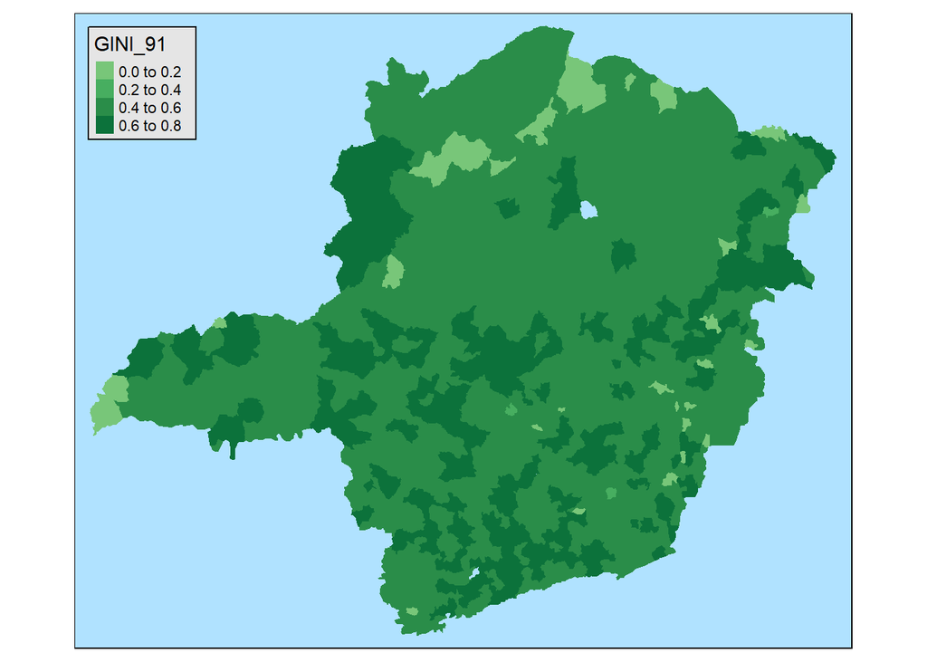

```r
tmap::tm_shape(crime_mg) +
  tmap::tm_fill("GINI_91", midpoint = 0) +
  tmap::tm_style("natural")
```